# Iris-dataset machine learning analysis

Here, let us show the basic information of the dataset:

There are four features: sepal width, sepal length, petal width, petal length.

There are three kinds of labels: (0,1,2): setosa, versicolor, virginica

Meanwhile, let us import some necessary packages.

```python
import numpy as np
import pandas as pd
import matplotlib.pyplot as plt
import seaborn as sns

from sklearn.datasets import load_iris
iris_orig=load_iris()
print (iris_orig)

x=pd.DataFrame(iris_orig.data)
y=pd.Series(iris_orig.target)
```

[output not shown]

[output cut: 101 more lines]

[output not shown]

And here, let us start the data-visualization. Here we will compose an "iris dataset" for the data-visualization.

```python
#print (x)
#print (y)
iris=pd.concat([x,y],axis=1)
iris.columns=["sepal width", "sepal length", "petal width", "petal length", "species"]
print (iris)
```

```
     sepal width  sepal length  petal width  petal length  species
0            5.1           3.5          1.4           0.2        0
1            4.9           3.0          1.4           0.2        0
2            4.7           3.2          1.3           0.2        0
3            4.6           3.1          1.5           0.2        0
4            5.0           3.6          1.4           0.2        0
5            5.4           3.9          1.7           0.4        0
6            4.6           3.4          1.4           0.3        0
7            5.0           3.4          1.5           0.2        0
8            4.4           2.9          1.4           0.2        0
9            4.9           3.1          1.5           0.1        0
10           5.4           3.7          1.5           0.2        0
11           4.8           3.4          1.6           0.2        0
12           4.8           3.0          1.4           0.1        0
13           4.3           3.0          1.1           0.1        0
```

[output cut: 49 more lines]

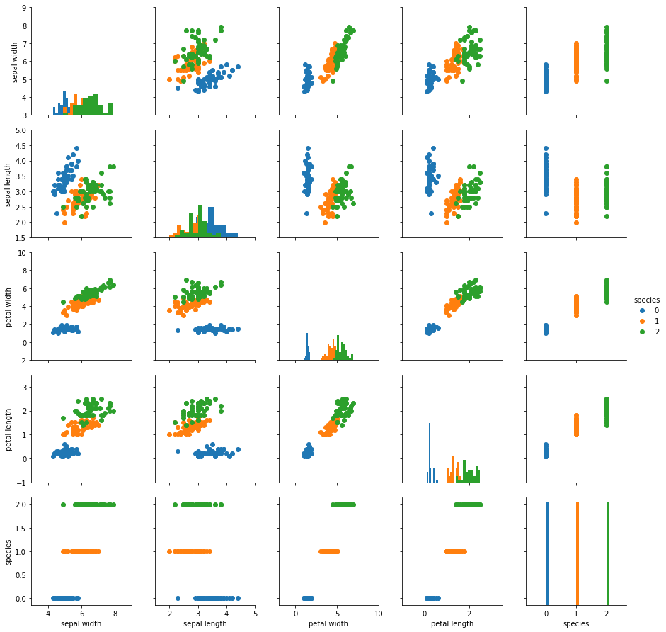

```python
g = sns.PairGrid(iris, hue="species")
g.map_diag(plt.hist)
g.map_offdiag(plt.scatter)
g.add_legend()

# Lets explicitly set the axes limits
axes = g.axes

lim = [(3, 9), (1.5, 5), (-2, 10), (-1, 3.5)]

for i in range(len(lim)):
    for j in range(len(lim)):
        axes[i, j].set_xlim(lim[j])
        axes[i, j].set_ylim(lim[i])
```

## Supervised learning

Here, let us introduce some machine learning algorithms. We will first divide the dataset into a training set, and then test the learned algorithm on test dataset(You will be amazed by how accurate it is!).

There are two datasets. First that is the dataset to be trained. Second, it is the dataset that never get trained, only get tested. You will soon realize that the machine learning algorithms really works!

```python
from sklearn.model_selection import train_test_split
x_train, x_test, y_train, y_test = train_test_split(x, y, test_size=0.2, random_state=42)
```

[output not shown]

[output cut: 80 more lines]

### KNN

```python
from sklearn import neighbors
from sklearn.metrics import classification_report
knn = neighbors.KNeighborsClassifier(n_neighbors=5)
knn.fit(x_train, y_train)
y_predict = knn.predict(x_test)
print (classification_report(y_test,y_predict))
```

```
              precision    recall  f1-score   support

           0       1.00      1.00      1.00        10
           1       1.00      1.00      1.00         9
           2       1.00      1.00      1.00        11

   micro avg       1.00      1.00      1.00        30
   macro avg       1.00      1.00      1.00        30
weighted avg       1.00      1.00      1.00        30
```

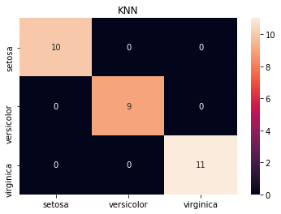

```python
def confusion(test, predict, title):
    # Define names for the three Iris types
    names = ['setosa', 'versicolor', 'virginica']

    # Make a 2D histogram from the test and result arrays
    pts, xe, ye = np.histogram2d(test, predict, bins=3)

    # For simplicity we create a new DataFrame
    pd_pts = pd.DataFrame(pts.astype(int), index=names, columns=names )

    # Display heatmap and add decorations
    hm = sns.heatmap(pd_pts, annot=True, fmt="d")
    hm.axes.set_title(title)

    return None
confusion(y_test,y_predict,"KNN")
```

### SVM

```python
from sklearn.svm import SVC
clf=SVC(kernel="linear",C=1)
clf.fit(x_train,y_train)
y_predict = clf.predict(x_test)
print (classification_report(y_test,y_predict))
#confusion(y_test,y_predict,"SVM")
```

```
              precision    recall  f1-score   support

           0       1.00      1.00      1.00        10
           1       1.00      1.00      1.00         9
           2       1.00      1.00      1.00        11

   micro avg       1.00      1.00      1.00        30
   macro avg       1.00      1.00      1.00        30
weighted avg       1.00      1.00      1.00        30
```

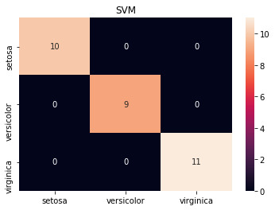

```python
confusion(y_test,y_predict,"SVM")
```

You may test with other supervised learning algorithms like decision tree, linear regression, etc. That is the homework.

## Unsupervised learning

### PCA

```python
from sklearn.decomposition import PCA
pca = PCA(n_components=2)
pca.fit(x)
data_reduced = pca.transform(x)
data_reduced2=pd.DataFrame(data_reduced)
print (data_reduced2)
data_reduced3=pd.concat([data_reduced2,y],axis=1)
```

```
            0         1
0   -2.684126  0.319397
1   -2.714142 -0.177001
2   -2.888991 -0.144949
3   -2.745343 -0.318299
4   -2.728717  0.326755
5   -2.280860  0.741330
6   -2.820538 -0.089461
7   -2.626145  0.163385
8   -2.886383 -0.578312
9   -2.672756 -0.113774
10  -2.506947  0.645069
11  -2.612755  0.014730
12  -2.786109 -0.235112
13  -3.223804 -0.511395
```

[output cut: 49 more lines]

### Clustering

```python
from sklearn.cluster import KMeans
k_means = KMeans(n_clusters=3, random_state=0)
k_means.fit(data_reduced3)
y_pred = k_means.predict(data_reduced3)
print (y_pred)
print (y)
```

```
[0 0 0 0 0 0 0 0 0 0 0 0 0 0 0 0 0 0 0 0 0 0 0 0 0 0 0 0 0 0 0 0 0 0 0 0 0
 0 0 0 0 0 0 0 0 0 0 0 0 0 2 2 2 2 2 2 2 2 2 2 2 2 2 2 2 2 2 2 2 2 2 2 2 2
 2 2 2 1 2 2 2 2 2 2 2 2 2 2 2 2 2 2 2 2 2 2 2 2 2 2 1 1 1 1 1 1 2 1 1 1 1
 1 1 1 1 1 1 1 1 1 1 1 1 1 1 1 1 1 1 1 1 1 1 1 1 1 1 1 1 1 1 1 1 1 1 1 1 1
 1 1]
0      0
1      0
2      0
3      0
4      0
5      0
6      0
7      0
8      0
9      0
```

[output cut: 52 more lines]

```python
print (classification_report(y,y_pred))
```

```
              precision    recall  f1-score   support

           0       1.00      1.00      1.00        50
           1       0.02      0.02      0.02        50
           2       0.02      0.02      0.02        50

   micro avg       0.35      0.35      0.35       150
   macro avg       0.35      0.35      0.35       150
weighted avg       0.35      0.35      0.35       150
```

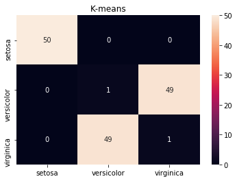

```python
confusion(y,y_pred,"K-means")
```